# Evaluating Formalised Models

Ulrich Losener

2022-01-22

# Markup Manuscript – Evaluating Formalised Theories

# 1 Introduction

An essential problem of psychological science is that its theories are often too vague, implicit and do not stem from a cumulative body of research (Meehl 1978). A potential solution lies in the formalisation of verbal psychological theories in the form of computational models. This forces researchers to be more specific, objective, and explicit about their theories (Guest and Martin 2020; Borsboom et al. 2021). Furthermore, previously implicit assumptions are made explicit (Smaldino 2017) which is important for good scientific practice (Walker 2003). In this study, we adress this problem by providing practical guidance for applied researchers who wish to build formal models. We create an example of a simple computational model of the mental disorder specific phobia based on a verbal model using a much simpler mathematical modeling approach than non-linear differential equations, the primary tool used in clinical psychology so far (Hosseinichimeh et al. 2016), (Robinaugh et al. 2020).

# 2 Model Building

## 2.1 The Verbal Model

The prevailing cognitive-behavioural theory of specific phobia is outlined by Kennerley, Kirk, and Westbrook (2016). This theory aims to explain specific phobia in terms of cognitive-behavioural reactions to phobic triggers. The core idea is that specific phobia develops and is maintained by a so-called “vicious cycle” whereby individuals experience phobic triggers and react with safety behaviours to escape or avoid those triggers. These behaviours in turn strengthen beliefs that the stimulus a threat.

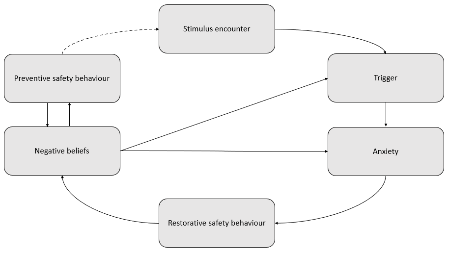

Graphical representation of the verbal model of specific phobia. Dotted arrows indicate anegative relationship.

## 2.2 The Computational Model

We formalise the verbal model using mathematical expressions and express it in a multivariate system that evolves over time. The variables and the relations specified in the verbal model will be preserved. The variables encounter, trigger, rsb, and psb are chosen to be a binary variables for simplicity. Anxiet} and belief are treated as discrete with four categories, respectively. This is done in order to be able to express more variation while still keeping some simplicity. To express the values of the variables at different timepoints, we use a Markov model – a stochastic process where the value of each variable at timepoint $t_{1}$ depends only on values at the nearest previous timepoint $t_{0}$ (called the Markov property). In Markov chains, “transition matrices” contain the probabilities of transitioning from one state to another. They are denoted by $P$ with $n$ rows $i=1,...,n$, $k$ columns $j=1, ...,k$, and $nk$ elements. We go from rows to columns, meaning that the rows refer to the current state of a variable at $t_{0}$ and the columns to the future state at $t_{1}$. Hence, the probability to transition from state $i$ to state $j$ is element $p_{ij}$, on row $i$ and column $j$ of $P$. In order for $P$ to be a valid transition matrix, all its entries must be positive ($p_{ij} \ge 0$, for all $i, j$) and all rows must sum up to one ($\sum_{i=1}^{n}p_{ij} = 1$, for all j).

### 2.2.1 Encounter

Encounter is zero when no phobic stimulus has been encountered at $t_{0}$ and one if there has been an encounter. This variable contains no information about how this stimulus is perceived (e.g., as a trigger).

$$P_{enc} = \left[\begin{array}
{rrr}
p_{00enc} & p_{01enc} \\
p_{10enc} & p_{11enc}
\end{array}\right]$$

where $p_{00}$ is the probability of the value for encounter to stay at zero when moving to the next time point, $p_{01}$ is the probability of the value to change from zero to one, $p_{10}$ from one to zero, and $p_{11}$ is the probability of the value staying at one. The elements of $P_{enc}$ depend on the presence of PSB the day before and are defined as follows:

$$\begin{align*}
p_{00enc}&=0.4+0.2psb_{t-1}\\
p_{01enc}&=1-p_{00enc}\\
p_{10enc}&=p_{00enc}\\
p_{11enc}&=p_{01enc}
\end{align*}$$

As can be seen from the definition of $p_{00enc}$, the probability of encountering no stimulus at timepoint $t_{0}$ after no stimulus has been encountered the previous day is .4 if PSB was absent the day before (at $t_{-1}$) and .6 if PSB was present. Note that in this case, the second row is identical to the first one. This means that the probability of encountering a relevant stimulus is not influenced by whether an encounter was present at $t_{-1}$ but only by whether PSB was present at $t_{-1}$. Strictly speaking, the transition matrix of this variable could therefore be replaced by a single linear regression, however, it is kept in matrix notation for the sake of consistency. We chose the values of 0.4 and 0.6 such that the Markov chain for this variable conforms to our educated guess about the occurrence of encounters. Our intuition is that these become less frequent when actively avoided.

### 2.2.2 Trigger

This binary variable indicates whether a stimulus is perceived as a threat ($0=no$, $1=yes$). With higher levels of negative belief towards a stimulus, the likelihood of being triggered increases Bouchard et al. (2012). In our model, we chose to allow triggers to occur even when the relevant stimulus is not encountered in vivo, just by the thought of an encounter and its consequences alone Kraft and Kraft (2010). We opted to make this scenario less likely than being triggered directly by an encounter.

The transition matrix of trigger is denoted by
$$P_{trig} = \left[\begin{array}
{rrr}
p_{00trig} & p_{01trig} \\
p_{10trig} & p_{11trig}
\end{array}\right]$$
The elements of $P_{trig}$ depend on the presence of an encounter at $t_{0}$ as well as the degree of negative belief towards the stimulus at $t_{-1}$ and are defined as follows:

$$\begin{align*}
p_{00trig}&=1-p_{01trig}\\
p_{01trig}&=0.2enc_{t0}(bel_{t-1}+1) + 0.15(1-enc_{t0})bel_{t-1}\\
p_{10trig}&=p_{00trig}\\
p_{11trig}&=p_{01trig}
\end{align*}$$

If there is no encounter at $t_{0}$, then the first term of $p_{01trig}$ becomes zero and only the second term remains. In this case, the probability of being triggered is $0.15bel_{t-1}$ – a number between 0 and .45 depending on the degree of negative belief. Hence, in this model, it is possible for a person to be triggered in absence of an encounter. Note that we chose the numbers 0.2 and 0.15 so that triggers would occur every few days.

### 2.2.3 Anxiety

The categorical variable anxiety} captures the level of phobic anxiety on a scale from zero to three, with higher values indicating higher levels of anxiety. Phobic anxiety can only be present if there is a trigger, and it increases with more negative beliefs.

The transition matrix of anxiety is denoted by
$$P_{anx} = \left[\begin{array}
{rrrr}
p_{00anx} & p_{01anx} & p_{02anx} & p_{03anx}\\
p_{10anx} & p_{11anx} & p_{12anx} & p_{13anx}\\
p_{20anx} & p_{21anx} & p_{22anx} & p_{23anx}\\
p_{30anx} & p_{31anx} & p_{32anx} & p_{33anx}
\end{array}\right]$$

Because anxiety can take on integers between zero and three, $P_{anx}$ is a 4x4 matrix. The elements of $P_{anx}$ depend on both the presence of a trigger and the degree of negative belief towards the feared stimulus. Please find the respective definitions in the appendix.

We chose transition probabilities of anxiety such that generally, the variable is more likely to transition to a value nearest to the previous one than it is to “jump” to a value beyond that. This was done so that anxiety levels do not change to fast from one day to another and that there is some coherence within persons, motivated by the fact that there is some stability of the trait “anxiety” within people Bieling, Antony, and Swinson (1998).

### 2.2.4 Restorative Safety Behaviour

This binary variable indicates the presence of behaviour directed at restoring perceived safety in an anxiety-inducing situation ($0=absent$, $1=present$). RSB can only be present when some level of anxiety is experienced (Goetz et al. 2016).

The transition matrix of RSB is denoted by
$$P_{rsb} = \left[\begin{array}
{rrr}
p_{00rsb} & p_{01rsb} \\
p_{10rsb} & p_{11rsb}
\end{array}\right]$$
The elements of $P_{rsb}$ depend on the level of anxiety at $t_{0}$ and are defined as follows:

$$\begin{align*}
p_{00rsb}&=1-p_{01rsb}\\
p_{01rsb}&=-e^{-anx_{t0}}+1\\
p_{10rsb}&=p_{00rsb}\\
p_{11rsb}&=-e^{-2anx_{t0}}+1
\end{align*}$$

The probability of RSB being present at $t_{0}$ is zero when there is no anxiety at $t_{0}$. With increasing levels of anxiety, the probability of RSB rises up to .95, as expressed by the negative exponential function of anxiety. If RSB were present the day before, a person is slightly more likely to engage in this behaviour again.

### 2.2.5 Preventive Safety Behaviour

This binary variable indicates the presence of behaviour directed at avoiding the fearful situation (Goetz et al. 2016). The occurrence of PSB is more likely when negative beliefs are stronger.

The transition matrix of PSB is denoted by
$$P_{psb} = \left[\begin{array}
{rrr}
p_{00psb} & p_{01psb} \\
p_{10psb} & p_{11psb}
\end{array}\right]$$
The elements of $P_{psb}$ depend on the level of negative belief at $t_{0}$ and are defined as follows:

### 2.2.6 Negative Belief

The variable negative belief entails the degree to which a person is convinced that the phobic stimulus is indeed dangerous. This variable is positively influenced by RSB and PSB, as the presence of one or both of these behaviours hinder a potential disconfirmation of the held belief (Goetz et al. 2016).

The transition matrix of negative belief is denoted by
$$P_{bel} = \left[\begin{array}
{rrrr}
p_{00bel} & p_{01bel} & p_{02bel} & p_{03bel}\\
p_{10bel} & p_{11bel} & p_{12bel} & p_{13bel}\\
p_{20bel} & p_{21bel} & p_{22bel} & p_{23bel}\\
p_{30bel} & p_{31bel} & p_{32bel} & p_{33bel}
\end{array}\right]$$

The elements of $P_{bel}$ depend on the presence of RSB and PSB. Please find their definitions in the appendix.

The formalisation of the model is computationally implemented as follows:

```r
# set number of timepoints, each timepoint represents one day
tpoints <- 30

# storing space and starting value for the binary variable "stimulus encounter"
enc <- rep(NA, tpoints)
enc[1] <- 0

# storing space and starting value for the binary variable "trigger"
trig <- rep(NA, tpoints)
trig[1] <- 0

# storing space and starting value for the categorical (0-3) variable "anxiety"
anx <- rep(NA, tpoints)
anx[1] <- 0

# storing space and starting value for the binary variable "restorative safety behaviour"
rsb <- rep(NA, tpoints)
rsb[1] <- 0

# storing space and starting value for the categorical (0-3) variable "belief"
bel <- rep(NA, tpoints)
bel[1] <- 0

# storing space and starting value for the binary variable "preventive safety behavior"
psb <- rep(NA, tpoints)
psb[1] <- 0
```

```r
# Set seed for reproducibility
set.seed(123)

for (i in 2:tpoints){
  # Transition probabilities of the variable "stimulus encounter"
  p00.enc <- .4+.2*psb[i-1]
  p01.enc <- 1-p00.enc
  p10.enc <- p00.enc
  p11.enc <- 1-p10.enc
  # Transition probabilities combined in matrix
  trans.enc <- matrix(c(p00.enc, p01.enc,
                        p10.enc, p11.enc), byrow=T, nrow=2)
  # Value for "stimulus encounter" is determined in each iteration as follows, the ifelse statement indicates which row of the transition matrix to use
  enc[i] <- ifelse(enc[i-1] == 0,
                 rbinom(1,1,prob=trans.enc[1,2]),
                 rbinom(1,1,prob=trans.enc[2,2]))

  # Transition probabilities of the variable "trigger"
  p01.trig <- .2*enc[i]*(bel[i-1]+1) + .15*(1-enc[i])*bel[i-1]
  p00.trig <- 1-p01.trig
  p11.trig <- p01.trig
  p10.trig <- p00.trig
  # Transition probabilities combined in matrix
  trans.trig <- matrix(c(p00.trig, p01.trig,
                         p10.trig, p11.trig), byrow=T, nrow=2)
  # Value for "trigger" is determined in each iteration as follows
  trig[i] <- ifelse(trig[i-1] == 0,
                 rbinom(1,1,prob=trans.trig[1,2]),
                 rbinom(1,1,prob=trans.trig[2,2]))

  # Transition probabilities of the variable "anxiety"
  p00.anx <- .3/(bel[i-1]+1)
  p01.anx <- .5/(bel[i-1]+1)
  p02.anx <- .2/(bel[i-1]+1)
  p03.anx <- 1-(p00.anx+p01.anx+p02.anx)
  p10.anx <- .1/(bel[i-1]+1)
  p11.anx <- .3/(bel[i-1]+1)
  p12.anx <- .6/(bel[i-1]+1)
  p13.anx <- 1-(p10.anx+p11.anx+p12.anx)
  p20.anx <- .1/(bel[i-1]+1)
  p21.anx <- .3/(bel[i-1]+1)
  p22.anx <- .5/(bel[i-1]+1)
  p23.anx <- 1-(p20.anx+p21.anx+p22.anx)
  p30.anx <- .1/(bel[i-1]+1)
  p31.anx <- .3/(bel[i-1]+1)
  p32.anx <- .5/(bel[i-1]+1)
  p33.anx <- 1-(p30.anx+p31.anx+p32.anx)
  # Transition probabilities combined in matrix
  trans.anx <- matrix(c(p00.anx, p01.anx, p02.anx, p03.anx,
                         p10.anx, p11.anx, p12.anx, p13.anx,
                         p20.anx, p21.anx, p22.anx, p23.anx,
                         p30.anx, p31.anx, p32.anx, p33.anx),
                       byrow = T, nrow = 4)
  # Value for "anxiety" is determined in each iteration as follows
  anx[i] <- if (trig[i]==0) {0}
             else if (trig[i]==1 & anx[i-1]==0) {
               sample(c(0,1,2,3), 1, prob=c(p00.anx,p01.anx,p02.anx,p03.anx))}
             else if (trig[i]==1 & anx[i-1]==1) {
               sample(c(0,1,2,3), 1, prob=c(p10.anx,p11.anx,p12.anx,p13.anx))}
             else if (trig[i]==1 & anx[i-1]==2) {
               sample(c(0,1,2,3), 1, prob=c(p20.anx,p21.anx,p22.anx,p23.anx))}
             else {
               sample(c(0,1,2,3), 1, prob=c(p30.anx,p31.anx,p32.anx,p33.anx))}

  # Transition probabilities of the variable "restorative safety behaviour"
  p01.rsb <- -exp(-anx[i])+1
  p00.rsb <- 1-p01.rsb
  p11.rsb <- -exp(-2*anx[i])+1
  p10.rsb <- 1-p11.rsb
  # Transition probabilities combined in matrix
  trans.rsb <- matrix(c(p00.rsb, p01.rsb,
                        p10.rsb, p11.rsb), byrow=T, nrow=2)
  # Value for "restorative safety behaviour" is determined in each iteration as follows
  rsb[i] <- ifelse(rsb[i-1] == 0,
                   rbinom(1,1,prob=trans.rsb[1,2]),
                   rbinom(1,1,prob=trans.rsb[2,2]))

  # Transition probabilities of the variable "negative belief"
  p00.bel <- if      (trig[i]==0)                                             {.9}
             else if (trig[i]==1 & rsb[i]==0 & psb[i-1]==0)                   {1}
             else if ((trig[i]==1 & rsb[i]==1) || (trig[i]==1 & psb[i-1]==1)) {.4}
             else                                                             {.1}
  p01.bel <- 1 - p00.bel
  p02.bel <- 0
  p03.bel <- 0

  p10.bel <- if      (trig[i]==0)                                             {0}
             else if (trig[i]==1 & rsb[i]==0 & psb[i-1]==0)                   {.8}
             else if ((trig[i]==1 & rsb[i]==1) || (trig[i]==1 & psb[i-1]==1)) {.1}
             else                                                             {0}
  p11.bel <- if      (trig[i]==0)                                             {.9}
             else if (trig[i]==1 & rsb[i]==0 & psb[i-1]==0)                   {.2}
             else if ((trig[i]==1 & rsb[i]==1) || (trig[i]==1 & psb[i-1]==1)) {.1}
             else                                                             {.1}
  p12.bel <- 1 - (p10.bel+p11.bel)
  p13.bel <- 0

  p20.bel <- 0
  p21.bel <- if      (trig[i]==0)                                             {0}
             else if (trig[i]==1 & rsb[i]==0 & psb[i-1]==0)                   {.9}
             else if ((trig[i]==1 & rsb[i]==1) || (trig[i]==1 & psb[i-1]==1)) {.1}
             else                                                             {0}
  p22.bel <- if      (trig[i]==0)                                             {.9}
             else if (trig[i]==1 & rsb[i]==0 & psb[i-1]==0)                   {.1}
             else if ((trig[i]==1 & rsb[i]==1) || (trig[i]==1 & psb[i-1]==1)) {.1}
             else                                                             {.1}
  p23.bel <- 1 - (p21.bel+p22.bel)

  p30.bel <- 0
  p31.bel <- 0
  p32.bel <- if      (trig[i]==0)                                             {.1}
             else if (trig[i]==1 & rsb[i]==0 & psb[i-1]==0)                   {.95}
             else if ((trig[i]==1 & rsb[i]==1) || (trig[i]==1 & psb[i-1]==1)) {.1}
             else                                                             {0}
  p33.bel <- 1 - (p30.bel+p32.bel)
  # Transition probabilities combined in matrix
  trans.bel <- matrix(c(p00.bel, p01.bel, p02.bel, p03.bel,
                        p10.bel, p11.bel, p12.bel, p13.bel,
                        p20.bel, p21.bel, p22.bel, p23.bel,
                        p30.bel, p31.bel, p32.bel, p33.bel),
                      byrow = T, nrow = 4)
  # Value for "negative belief" is determined in each iteration as follows
  bel[i] <- if (bel[i-1]==0) {
              sample(c(0, 1, 2, 3), 1, prob=c(p00.bel,p01.bel,p02.bel,p03.bel))}
            else if (bel[i-1]==1) {
              sample(c(0, 1, 2, 3), 1, prob=c(p10.bel,p11.bel,p12.bel,p13.bel))}
            else if (bel[i-1]==2) {
              sample(c(0, 1, 2, 3), 1, prob=c(p20.bel,p21.bel,p22.bel,p23.bel))}
            else {
              sample(c(0, 1, 2, 3), 1, prob=c(p30.bel,p31.bel,p32.bel,p33.bel))}

  # Value for "preventive safety behaviour" is determined in each iteration as follows
  psb[i] <- if      (bel[i]==0) {0}
            else if (bel[i]==1) {rbinom(1,1,prob=.5)}
            else if (bel[i]==2) {rbinom(1,1,prob=.7)}
            else                {rbinom(1,1,prob=.9)}

}
```

# 3 Data generation

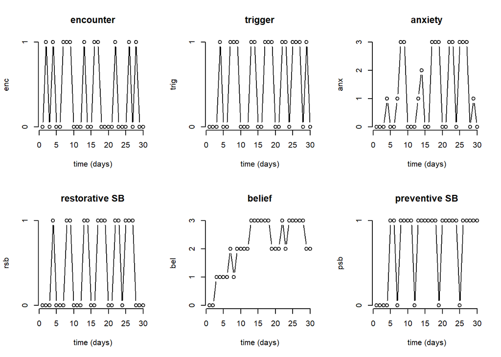

# References

Bieling, Peter J, Martin M Antony, and Richard P Swinson. 1998. “The State–Trait Anxiety Inventory, Trait Version: Structure and Content Re-Examined.” *Behaviour Research and Therapy* 36 (7-8): 777–88.

Böhnlein, Joscha, Luisa Altegoer, Nina Kristin Muck, Kati Roesmann, Ronny Redlich, Udo Dannlowski, and Elisabeth J Leehr. 2020. “Factors Influencing the Success of Exposure Therapy for Specific Phobia: A Systematic Review.” *Neuroscience & Biobehavioral Reviews* 108: 796–820.

Borsboom, Denny, Han LJ van der Maas, Jonas Dalege, Rogier A Kievit, and Brian D Haig. 2021. “Theory Construction Methodology: A Practical Framework for Building Theories in Psychology.” *Perspectives on Psychological Science*, 1745691620969647.

Bouchard, Stéphane, Geneviève Robillard, Serge Larouche, and Claudie Loranger. 2012. “Description of a Treatment Manual for in Virtuo Exposure with Specific Phobia.” *Virtual Reality in Psychological, Medical and Pedagogical Applications*, 82–108.

Choy, Yujuan, Abby J Fyer, and Josh D Lipsitz. 2007. “Treatment of Specific Phobia in Adults.” *Clinical Psychology Review* 27 (3): 266–86.

Goetz, Amy R, Taylor P Davine, Stephan G Siwiec, and Han-Joo Lee. 2016. “The Functional Value of Preventive and Restorative Safety Behaviors: A Systematic Review of the Literature.” *Clinical Psychology Review* 44: 112–24.

Guest, Olivia, and Andrea E Martin. 2020. “How Computational Modeling Can Force Theory Building in Psychological Science.” *Perspectives on Psychological Science*, 1745691620970585.

Hosseinichimeh, Niyousha, Hazhir Rahmandad, Mohammad S Jalali, and Andrea K Wittenborn. 2016. “Estimating the Parameters of System Dynamics Models Using Indirect Inference.” *System Dynamics Review* 32 (2): 156–80.

Kennerley, Helen, Joan Kirk, and David Westbrook. 2016. *An Introduction to Cognitive Behaviour Therapy: Skills and Applications*. Sage.

Kraft, David, and Tom Kraft. 2010. “Use of in Vivo and in Vitro Desensitization in the Treatment of Mouse Phobia: Review and Case Study.” *Contemporary Hypnosis* 27 (3): 184–94.

Meehl, Paul E. 1978. “Theoretical Risks and Tabular Asterisks: Sir Karl, Sir Ronald, and the Slow Progress of Soft Psychology.” *Journal of Consulting and Clinical Psychology* 46 (4): 806.

Robinaugh, Donald J, Jonas MB Haslbeck, Oisı́n Ryan, Eiko I Fried, and Lourens J Waldorp. 2020. “Invisible Hands and Fine Calipers: A Call to Use Formal Theory as a Toolkit for Theory Construction.” *Perspectives on Psychological Science*, 1745691620974697.

Smaldino, Paul E. 2017. “Models Are Stupid, and We Need More of Them.” In *Computational Social Psychology*, 311–31. Routledge.

Walker, Charles A. 2003. “Making Assumptions Explicit.” *Journal of Theory Construction and Testing* 7 (2): 37–39.

# Appendix

Transition probabilities of the variable negative belief:

$$\begin{align*}
p_{00bel}&=\begin{cases}
0.9 & \quad \text{if } trig_{t0}=0\\
1 & \quad \text{if } trig_{t0}=1 \bigcup rsb_{t0}=1 \bigcup psb_{t0}=1\\
0.4 & \quad \text{if } (trig_{t0}=1 \bigcup rsb_{t0}=1) \bigcap (trig_{t0}=1 \bigcup psb_{t0}=1)\\
0.1 & \quad \text{else}
\end{cases}\\
p_{01bel}&=1-p_{00bel}\\
p_{02bel}&=0\\
p_{03bel}&=0\\
p_{10bel}&=\begin{cases}
0 & \quad \text{if } trig_{t0}=0\\
0.8 & \quad \text{if } trig_{t0}=1 \bigcup rsb_{t0}=1 \bigcup psb_{t0}=1\\
0.1 & \quad \text{if } (trig_{t0}=1 \bigcup rsb_{t0}=1) \bigcap (trig_{t0}=1 \bigcup psb_{t0}=1)\\
0 & \quad \text{else}
\end{cases}\\
p_{11bel}&=\begin{cases}
0.9 & \quad \text{if } trig_{t0}=0\\
0.2 & \quad \text{if } trig_{t0}=1 \bigcup rsb_{t0}=1 \bigcup psb_{t0}=1\\
0.1 & \quad \text{if } (trig_{t0}=1 \bigcup rsb_{t0}=1) \bigcap (trig_{t0}=1 \bigcup psb_{t0}=1)\\
0.1 & \quad \text{else}
\end{cases}\\
p_{12bel}&=1-(p_{10bel}+p_{11bel})\\
p_{13bel}&=0\\
p_{20bel}&=0\\
p_{21bel}&=\begin{cases}
0 & \quad \text{if } trig_{t0}=0\\
0.9 & \quad \text{if } trig_{t0}=1 \bigcup rsb_{t0}=1 \bigcup psb_{t0}=1\\
0.1 & \quad \text{if } (trig_{t0}=1 \bigcup rsb_{t0}=1) \bigcap (trig_{t0}=1 \bigcup psb_{t0}=1)\\
0 & \quad \text{else}
\end{cases}\\
p_{22bel}&=\begin{cases}
0.9 & \quad \text{if } trig_{t0}=0\\
0.1 & \quad \text{if } trig_{t0}=1 \bigcup rsb_{t0}=1 \bigcup psb_{t0}=1\\
0.1 & \quad \text{if } (trig_{t0}=1 \bigcup rsb_{t0}=1) \bigcap (trig_{t0}=1 \bigcup psb_{t0}=1)\\
0.1 & \quad \text{else}
\end{cases}\\
p_{23bel}&=1-(p_{21bel}+p_{22bel})\\
p_{30bel}&=0\\
p_{31bel}&=0\\
p_{32bel}&=\begin{cases}
0.1 & \quad \text{if } trig_{t0}=0\\
0.95 & \quad \text{if } trig_{t0}=1 \bigcup rsb_{t0}=1 \bigcup psb_{t0}=1\\
0.1 & \quad \text{if } (trig_{t0}=1 \bigcup rsb_{t0}=1) \bigcap (trig_{t0}=1 \bigcup psb_{t0}=1)\\
0 & \quad \text{else}
\end{cases}\\
p_{33bel}&=1-p_{32bel}\\
\end{align*}$$